# HW3-Oya Hoban

Oya Hoban - IE360 - Spring 2021

06 06 2021

In this homework,we are trying to predict 14 days (from 7th of May to 20th of May in 2021) of Electricity Consumption of Turkey by using the Electricity consumption data obtained from [EPİAŞ](https://seffaflik.epias.com.tr/transparency/tuketim/gerceklesen-tuketim/gercek-zamanli-tuketim.xhtml). The data used include the dates from 2016, January to 2021 May. In order to build prediction models, firstly decomposition of series are executed, then decided on Auto Regressive or Moving Average method to build the necessary model.

# 1.)Getting to Know the Series

## 1.1)Hourly Electricity Consumption

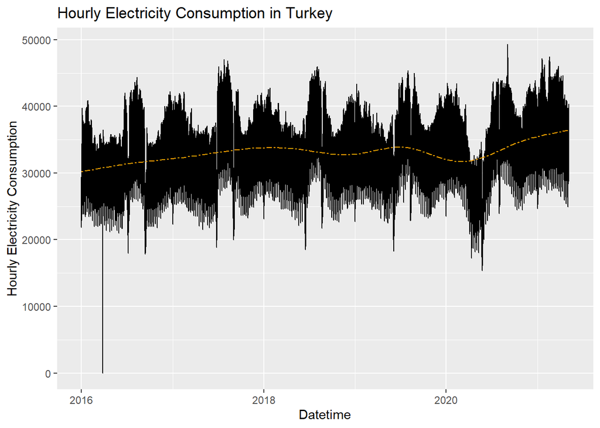

Figure 1.1- Hourly Electricity Consumption in Turkey

```
##
## #######################
## # KPSS Unit Root Test #
## #######################
##
## Test is of type: mu with 18 lags.
##
## Value of test-statistic is: 13.3085
##
## Critical value for a significance level of:
##                 10pct  5pct 2.5pct  1pct
## critical values 0.347 0.463  0.574 0.739
```

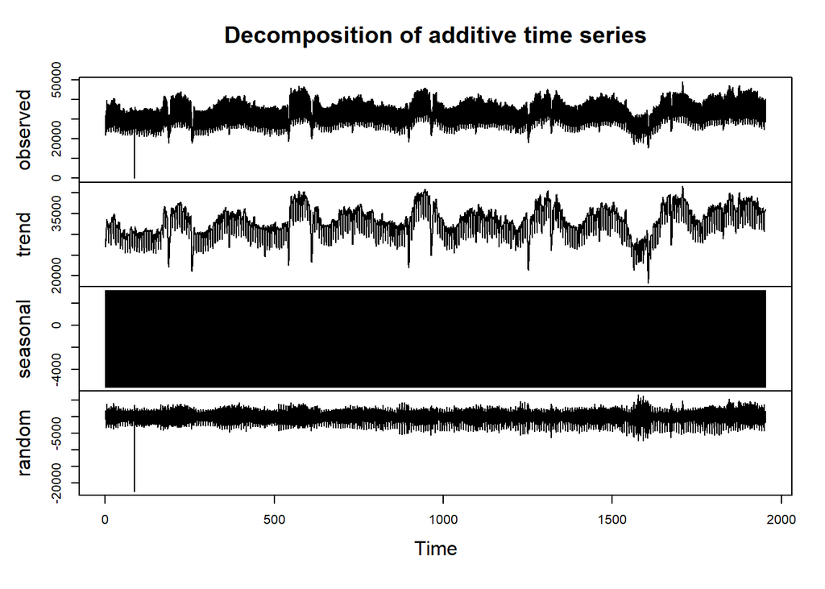

Figure 1.2- Hourly Electricity Consumption Decomposition

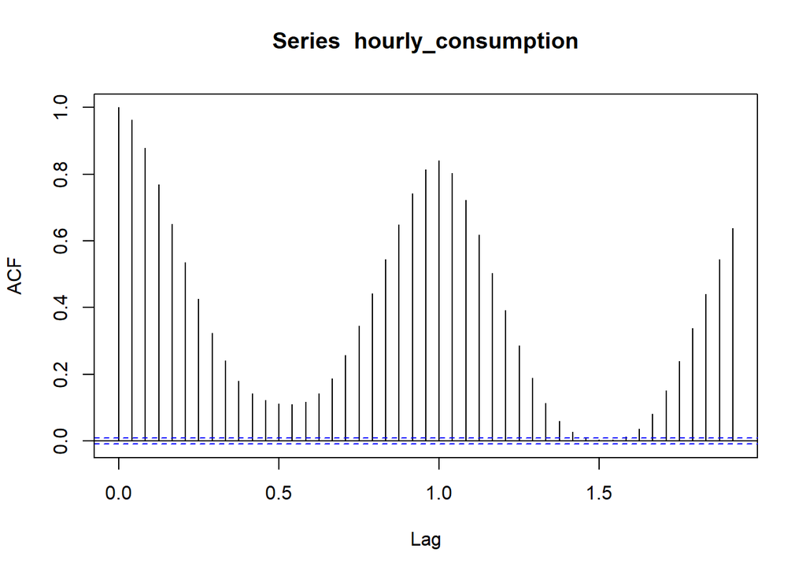

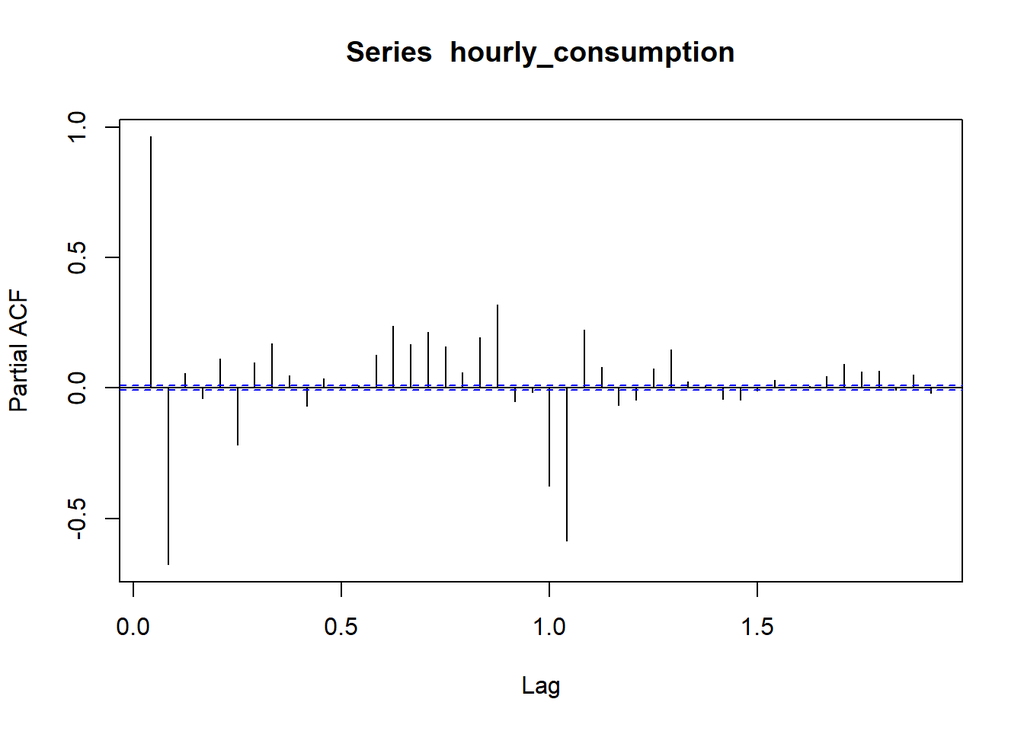

```
##
## #######################
## # KPSS Unit Root Test #
## #######################
##
## Test is of type: mu with 18 lags.
##
## Value of test-statistic is: 3e-04
##
## Critical value for a significance level of:
##                 10pct  5pct 2.5pct  1pct
## critical values 0.347 0.463  0.574 0.739
```

After decomposing the hourly series with frequency 24,we can clearly see the trend part of the series, however seasonality part can not be observed as clearly. And looking at the random part, which is the part without the seasonality and trend, it fits the random distribution with zero mean and constant variance. And after the execution of the KPSS unit root test on the random part of decomposed hourly series, the value of the test statistic is much smaller than the critical values, so we fail to reject the null hypothesis and we can say that the random part is stationary.

On the graph of ACF we see a peak at the 24th lag, this may be an indicator for there is an 24 hourly/daily pattern in the series.

## 1.2)Average Daily Electricity Consumption

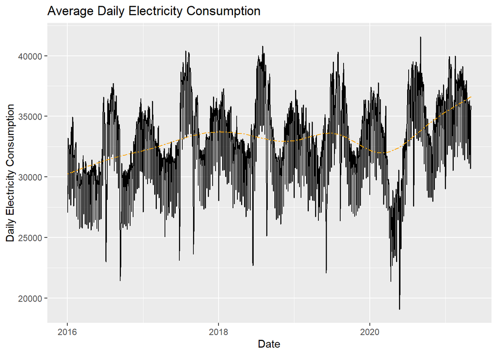

Figure 1.3- Daily Electricity Consumption in Turkey Line Graph

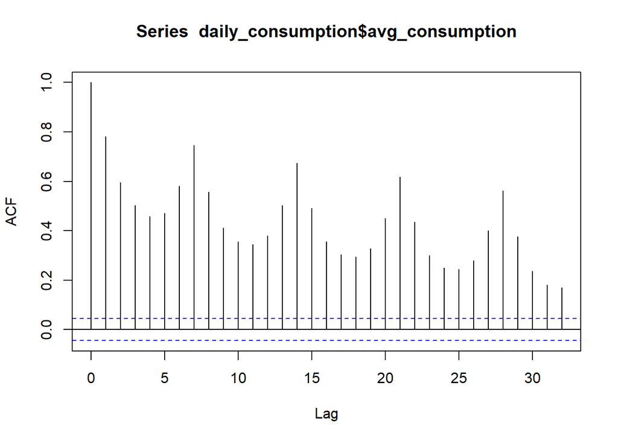

```
##
## #######################
## # KPSS Unit Root Test #
## #######################
##
## Test is of type: mu with 8 lags.
##
## Value of test-statistic is: 1.9401
##
## Critical value for a significance level of:
##                 10pct  5pct 2.5pct  1pct
## critical values 0.347 0.463  0.574 0.739
```

When we take the daily average of hourly series, and plot it, we get a more clear graph, we can also observe that the daily series is not stationary as well. Applying the KPSS Unit root test, the value is higher than the critical values, so we reject the null hypothesis. Also, looking at the ACF graph, we observe a peak at lag 7, so this could be an indicator that there may be an cyclic behavior of the series in a 7 day cycle. And since we don’t observe an increasing variance over the series, we can use additive decomposition.

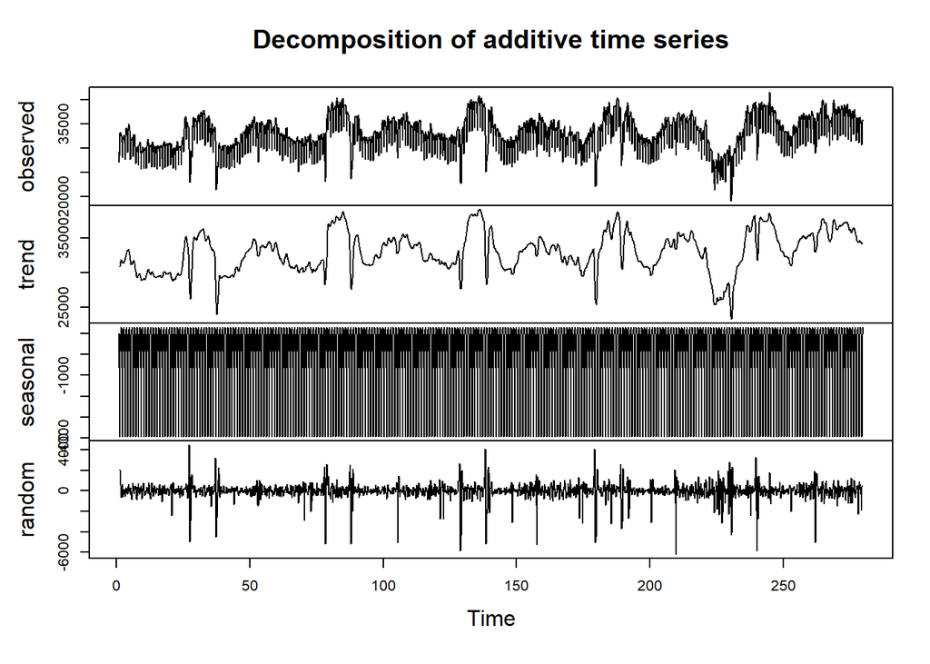

Figure 1.3- Daily Electricity Consumption Decomposition

```
##
## #######################
## # KPSS Unit Root Test #
## #######################
##
## Test is of type: mu with 8 lags.
##
## Value of test-statistic is: 0.0039
##
## Critical value for a significance level of:
##                 10pct  5pct 2.5pct  1pct
## critical values 0.347 0.463  0.574 0.739
```

After decomposing the daily series with frequency 7,we can clearly see the trend part of the series. And looking at the random part, which is the part without the seasonality and trend, it fits the random distribution with zero mean and constant variance, with some peaks, probably due to holidays and special days. And after the execution of the KPSS unit root test on the random part of decomposed daily series, the value of the test statistic is much smaller than the critical values, so we fail to reject the null hypothesis and we can say that the random part is stationary.

## 2.1) Decomposition of the Hourly Series with 168 Hour Frequency

After obtaining the information that, there may be a 24 hour frequency in the hourly series and 7 day frequency in the daily series, it may be good to decompose the hourly series with 24 hour* 7 day = 168 hour frequency, so that we could detect seasonality better.Also, using additive decomposition since we don’t see increasing variance in the series.

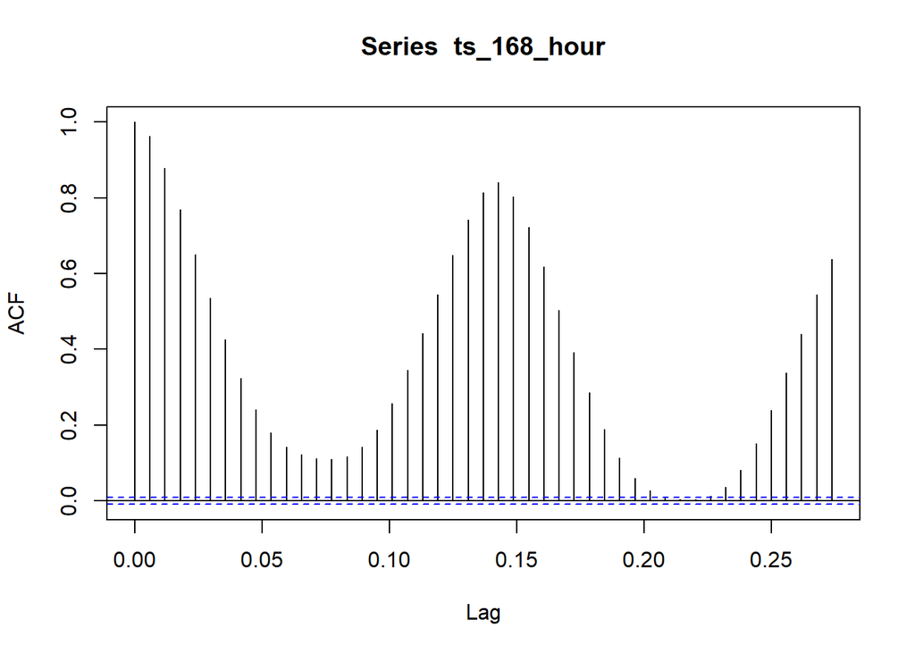

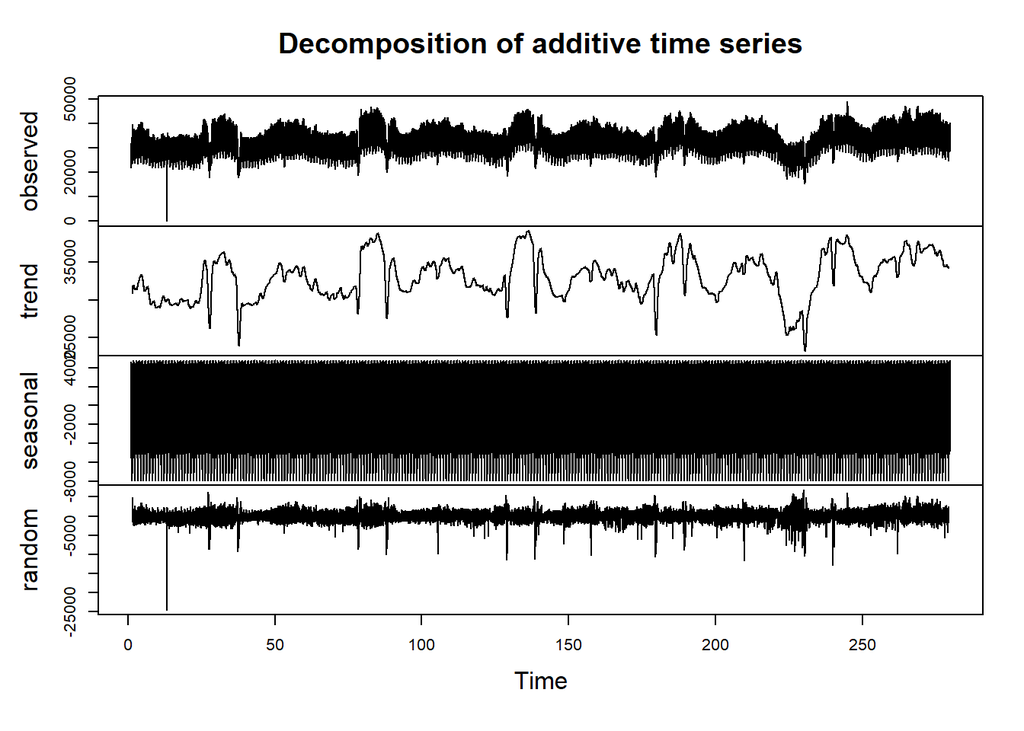

```
##
## #######################
## # KPSS Unit Root Test #
## #######################
##
## Test is of type: mu with 18 lags.
##
## Value of test-statistic is: 0.0015
##
## Critical value for a significance level of:
##                 10pct  5pct 2.5pct  1pct
## critical values 0.347 0.463  0.574 0.739
```

After decomposing, we can see that random part is stationary, we use KPSS unit rot test to test it, and the value of the test statistic is small enough to fail to reject the null hypothesis. SO, we can use the random part to build our model.

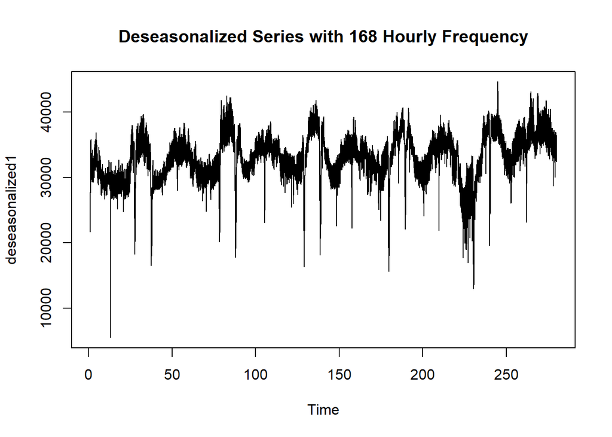

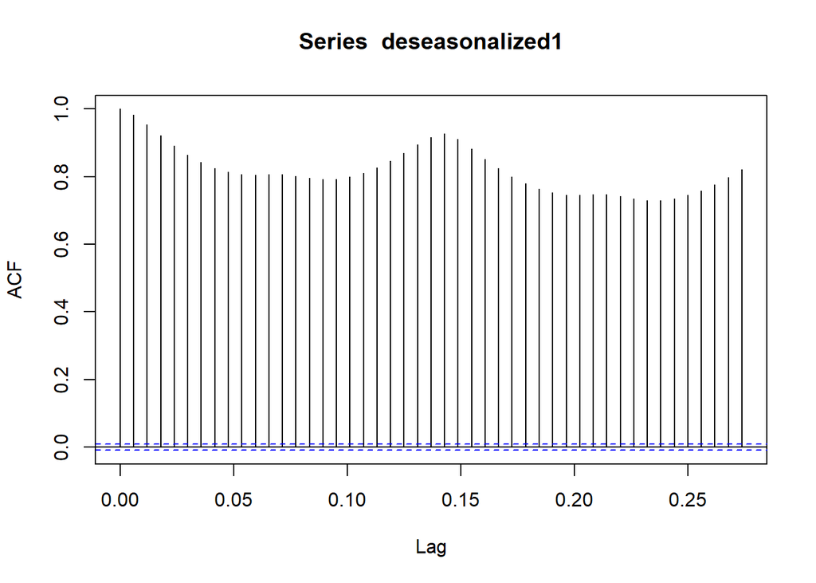

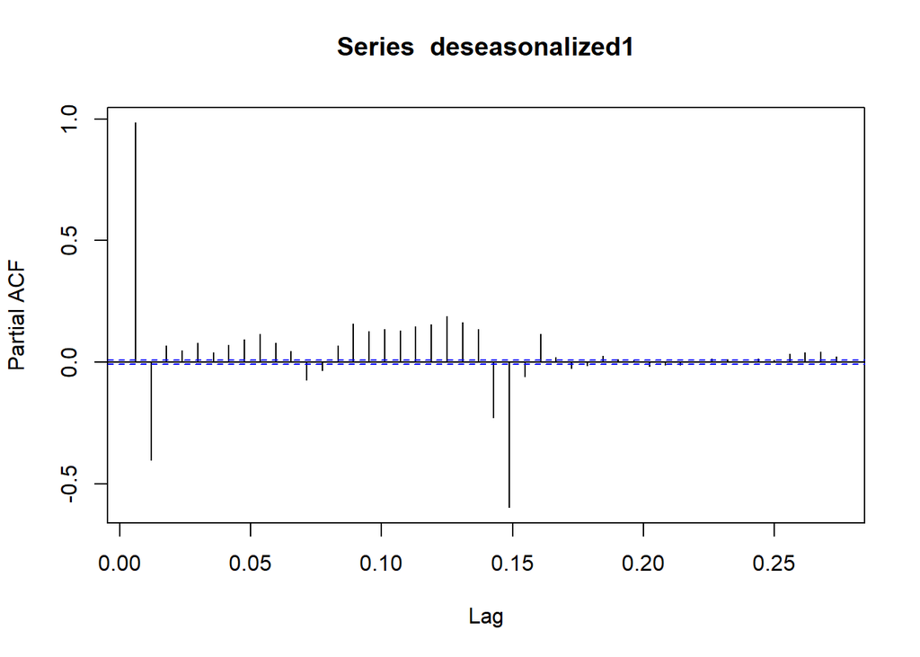

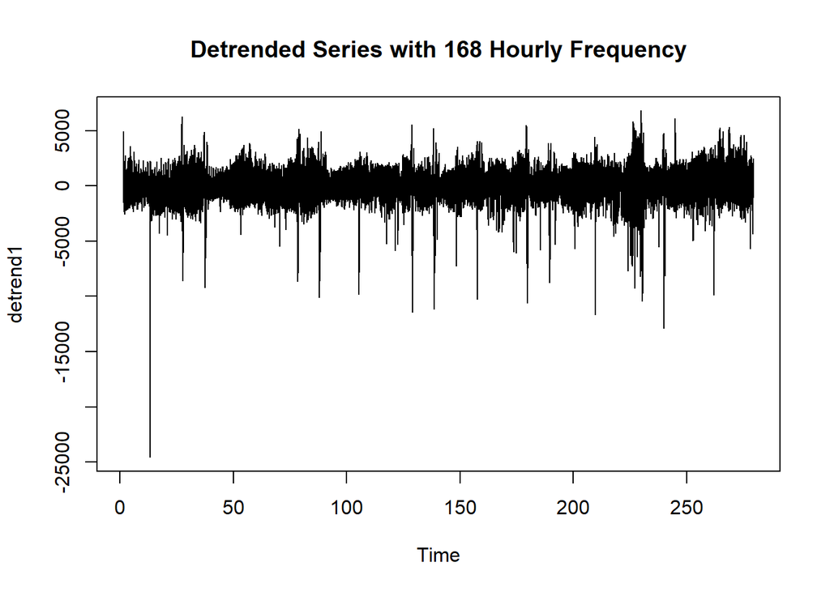

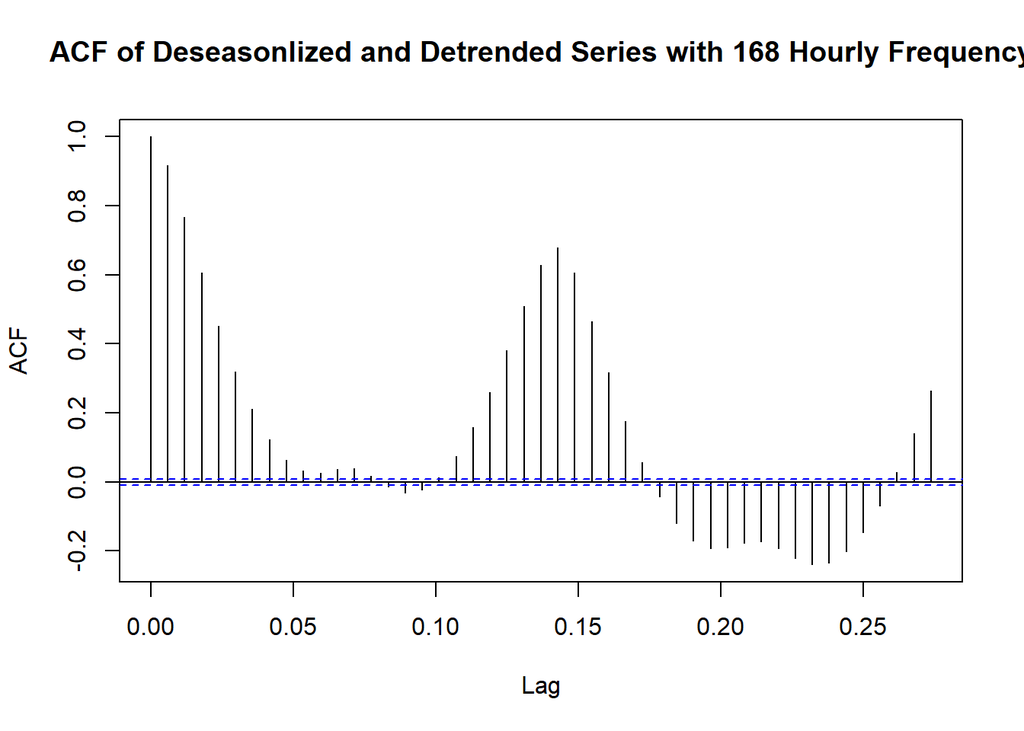

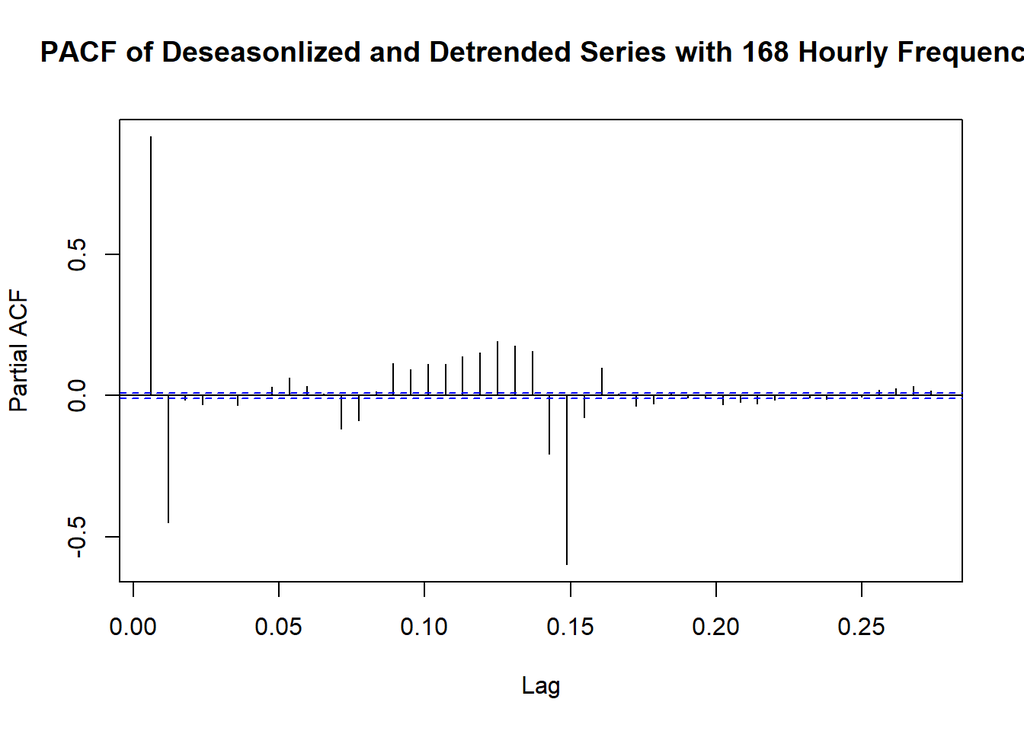

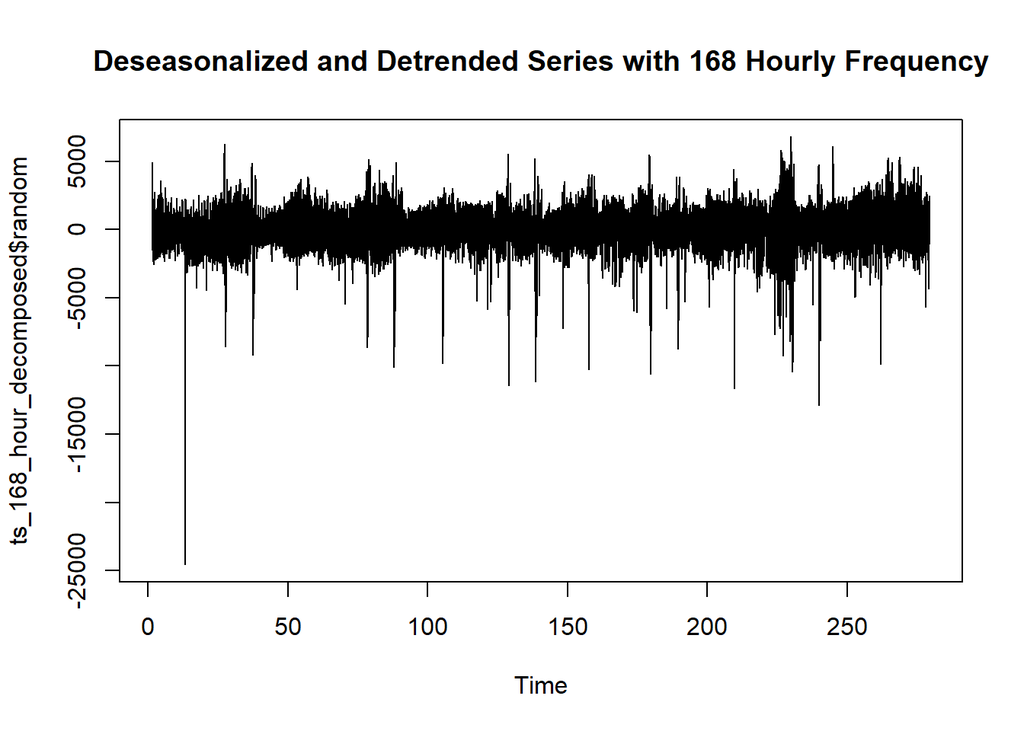

```
##
## Call:
## arima(x = detrend1, order = c(1, 0, 0))
##
## Coefficients:
##          ar1  intercept
##       0.9166     0.1335
## s.e.  0.0018    32.6277
##
## sigma^2 estimated as 345531:  log likelihood = -364075.2,  aic = 728156.5
```

```
## [1] 728156.5
```

```
## [1] 728182.8
```

```
##
## Call:
## arima(x = detrend1, order = c(24, 0, 0))
##
## Coefficients:
##          ar1      ar2     ar3      ar4     ar5     ar6    ar7      ar8     ar9
##       1.1809  -0.3498  0.0454  -0.0613  0.0472  -0.023  0.007  -0.0358  0.0312
## s.e.  0.0045   0.0069  0.0070   0.0070  0.0070   0.007  0.007   0.0070  0.0070
##          ar10    ar11    ar12     ar13     ar14    ar15     ar16    ar17
##       -0.0587  0.0974  0.0094  -0.0102  -0.0957  0.0436  -0.0177  0.0211
## s.e.   0.0070  0.0070  0.0070   0.0070   0.0070  0.0070   0.0070  0.0070
##          ar18    ar19     ar20    ar21     ar22    ar23     ar24  intercept
##       -0.0138  0.0304  -0.0407  0.0434  -0.0805  0.3959  -0.2086     0.1486
## s.e.   0.0070  0.0070   0.0070  0.0070   0.0070  0.0069   0.0045    49.3879
##
## sigma^2 estimated as 212493:  log likelihood = -352724.9,  aic = 705501.8
```

```
## [1] 705501.8
```

```
## [1] 705729.4
```

```
##
## Call:
## arima(x = detrend1, order = c(0, 1, 0))
##
##
## sigma^2 estimated as 360542:  log likelihood = -365059.6,  aic = 730121.3
```

```
## [1] 730121.3
```

```
## [1] 730130
```

```
##
## Call:
## arima(x = detrend1, order = c(0, 0, 1))
##
## Coefficients:
##          ma1  intercept
##       0.8526     0.1322
## s.e.  0.0018     7.5284
##
## sigma^2 estimated as 771235:  log likelihood = -382824.6,  aic = 765655.2
```

```
## [1] 765655.2
```

```
## [1] 765681.4
```

After deseasonalizing and detrending the decomposed series, when we look at the ACF and PACF graph of the random part, we can see that in ACF there is sinusodial pattern and in PACF there is significant peak at lag 1 and lag 24, so we can try to use AR(1) and AR(24) to model the series, also we can try different ARIMA models as well, and decide which one to use depending on their AIC and BIC values. And out of all models, we see the smallest AIC value in ARIMA(24,0,0) model, so we can use it to build our prediction model.

## 2.2) Decomposition of the Daily Series with 7 Day Frequency

In part 1, we also detected that there may be a 7 day seasonality in the series as well. We can try to see how the model would work in a daily series compared to hourly series, with a more aggregate approach with daiy series.

So, firstly we deseasonalize and detrend the series with 7 day frequency.

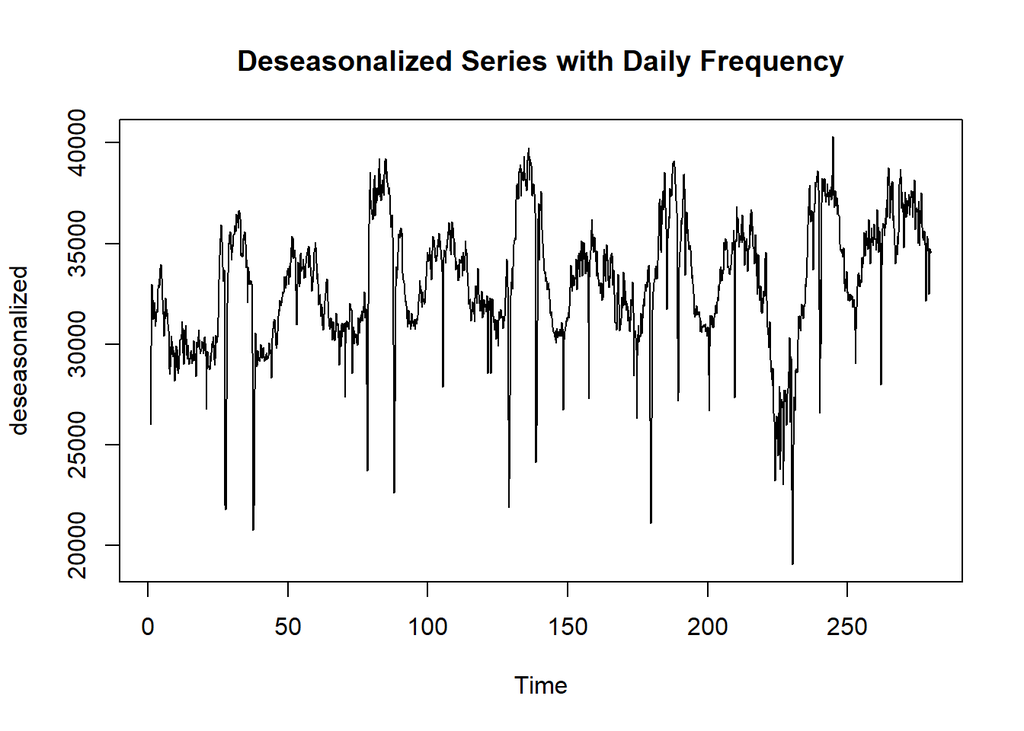

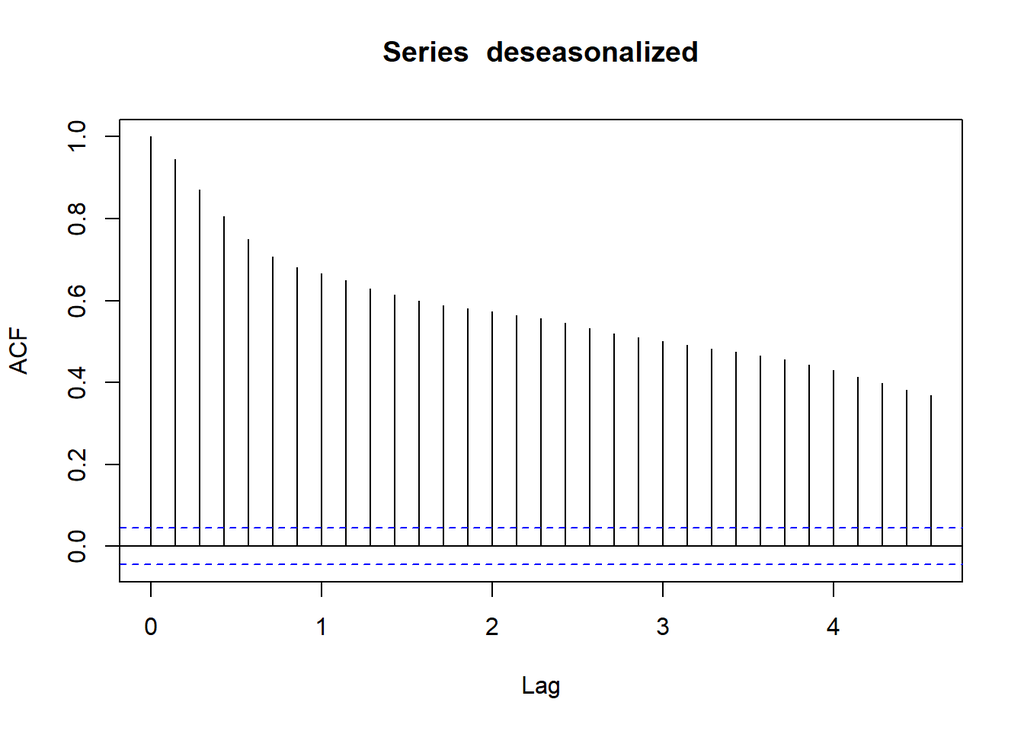

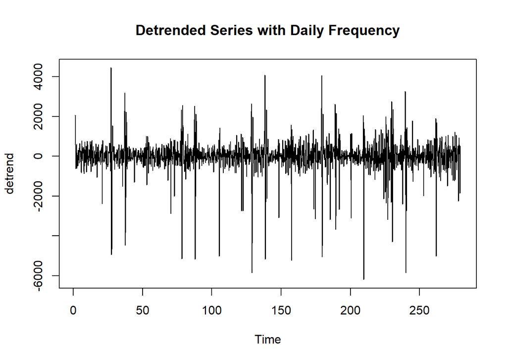

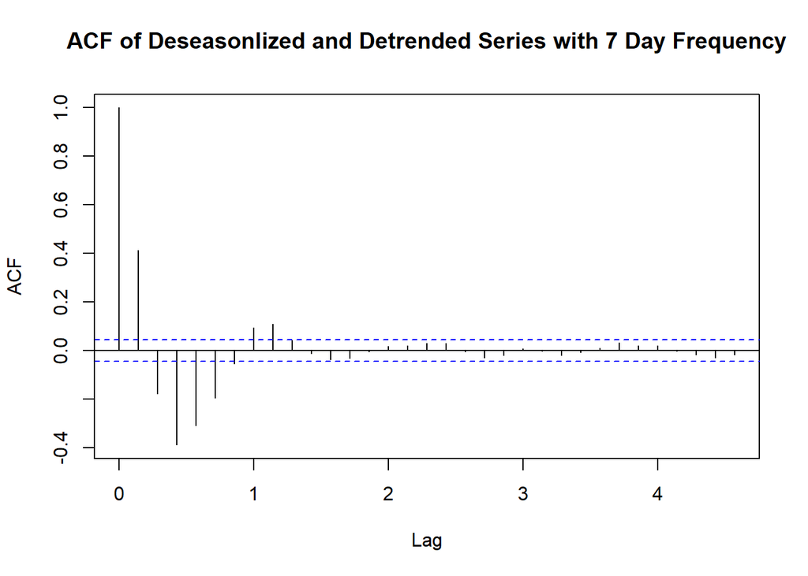

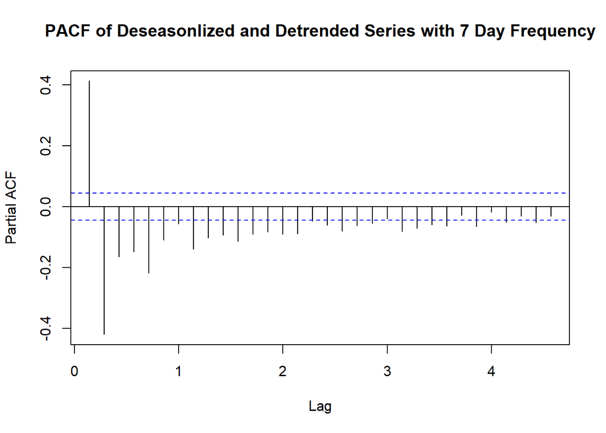

```
##
## Call:
## arima(x = detrend, order = c(1, 0, 0))
##
## Coefficients:
##          ar1  intercept
##       0.4138     0.8258
## s.e.  0.0207    29.6586
##
## sigma^2 estimated as 588861:  log likelihood = -15696.63,  aic = 31399.27
```

```
## [1] 31399.27
```

```
## [1] 31415.99
```

```
##
## Call:
## arima(x = detrend, order = c(0, 1, 0))
##
##
## sigma^2 estimated as 832359:  log likelihood = -16025.21,  aic = 32052.42
```

```
## [1] 32052.42
```

```
## [1] 32057.99
```

```
##
## Call:
## arima(x = detrend, order = c(0, 0, 1))
##
## Coefficients:
##          ma1  intercept
##       0.5319     0.7960
## s.e.  0.0168    25.3982
##
## sigma^2 estimated as 535359:  log likelihood = -15603.98,  aic = 31213.96
```

```
## [1] 31213.96
```

```
## [1] 31230.68
```

```
##
## Call:
## arima(x = detrend, order = c(1, 0, 1))
##
## Coefficients:
##          ar1     ma1  intercept
##       0.1066  0.4674     0.8652
## s.e.  0.0348  0.0281    27.1677
##
## sigma^2 estimated as 532917:  log likelihood = -15599.54,  aic = 31207.08
```

```
## [1] 31207.08
```

```
## [1] 31229.38
```

```
##
## Call:
## arima(x = detrend, order = c(4, 0, 0))
##
## Coefficients:
##          ar1      ar2      ar3      ar4  intercept
##       0.4942  -0.3715  -0.0880  -0.1476     0.7084
## s.e.  0.0224   0.0250   0.0251   0.0225    13.8442
##
## sigma^2 estimated as 461608:  log likelihood = -15459.89,  aic = 30931.78
```

```
## [1] 30931.78
```

```
## [1] 30965.23
```

```
##
## Call:
## arima(x = detrend, order = c(7, 0, 0))
##
## Coefficients:
##          ar1      ar2      ar3      ar4      ar5      ar6      ar7  intercept
##       0.4323  -0.4042  -0.1919  -0.0925  -0.1892  -0.0845  -0.0556     0.5338
## s.e.  0.0227   0.0246   0.0260   0.0263   0.0260   0.0247   0.0227     9.4174
##
## sigma^2 estimated as 433225:  log likelihood = -15398.28,  aic = 30814.57
```

```
## [1] 30814.57
```

```
## [1] 30864.73
```

After deseasonalizing and detrending the decomposed series, when we look at the ACF and PACF graph of the random part, we can see that in ACF there is sinusodial pattern and in PACF there is significant peak at lag 1 , lag 4 and lag7, so we can try to use AR(1) ,AR(4) and AR(7) to model the series, also we can try different ARIMA models as well, and decide which one to use depending on their AIC and BIC values. And out of all models, we see the smallest AIC value in ARIMA(7,0,0) model, so we can use it to build our prediction model.

# 3.) Predicting 14 Days of Electricity Consumption in Turkey

## 3.1) Prediction Based on the Model that is Built with Series of 168 Hour Frequency

In order to build our prediction model, we are going to used random part of the decomposed series, with using the best ARIMA model that we have obtained, in this case this will be ARIMA(24,0,0) that we have obtained in part 2.1 for the hourly series with 168 hour frequency.

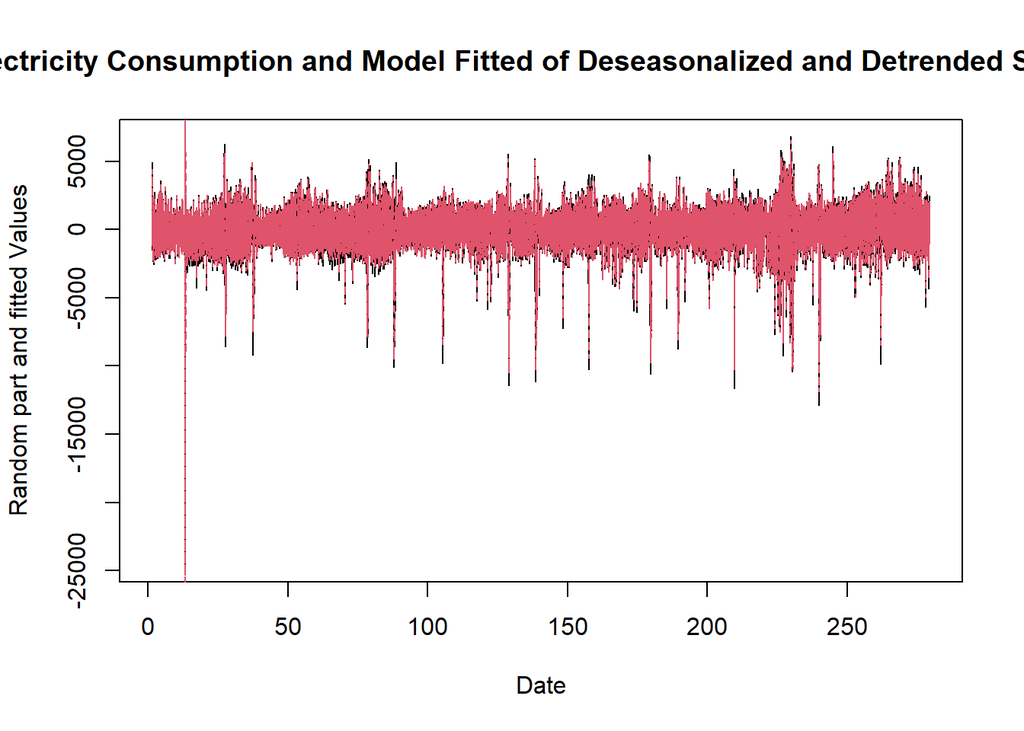

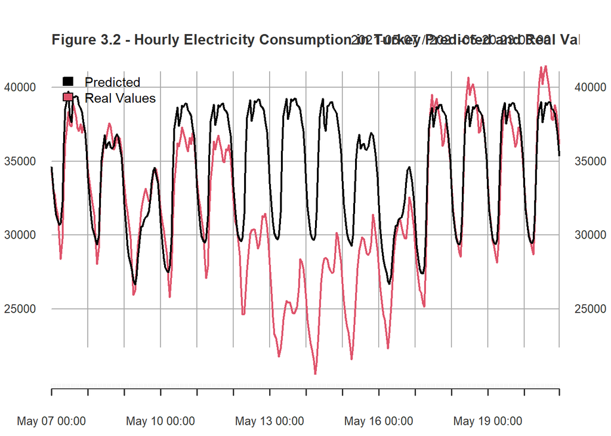

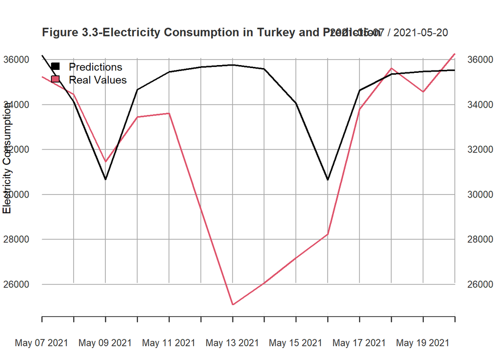

[output not shown]

[output cut: 282 more lines]

```
## 2021-05-20 09:00:00             2.916291747 2021-05-20 09:00:00
## 2021-05-20 10:00:00             4.676974060 2021-05-20 10:00:00
## 2021-05-20 11:00:00             5.722479583 2021-05-20 11:00:00
## 2021-05-20 12:00:00             6.424698820 2021-05-20 12:00:00
## 2021-05-20 13:00:00             6.648828083 2021-05-20 13:00:00
## 2021-05-20 14:00:00             6.072954615 2021-05-20 14:00:00
## 2021-05-20 15:00:00             4.853728770 2021-05-20 15:00:00
## 2021-05-20 16:00:00             3.092435778 2021-05-20 16:00:00
## 2021-05-20 17:00:00             0.543683752 2021-05-20 17:00:00
## 2021-05-20 18:00:00             1.836502506 2021-05-20 18:00:00
## 2021-05-20 19:00:00             1.840693536 2021-05-20 19:00:00
## 2021-05-20 20:00:00             1.433851834 2021-05-20 20:00:00
## 2021-05-20 21:00:00             2.251090756 2021-05-20 21:00:00
## 2021-05-20 22:00:00             2.111577031 2021-05-20 22:00:00
## 2021-05-20 23:00:00             2.203609099 2021-05-20 23:00:00
```

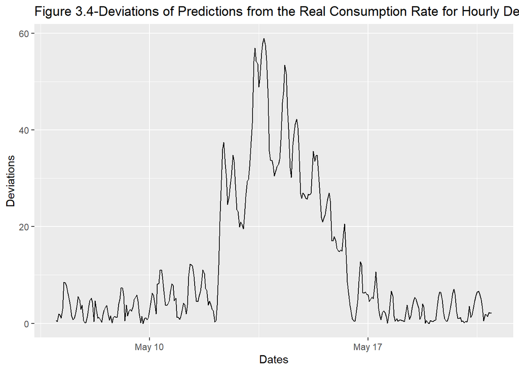

```
## [1] " Weighted Mean Absolute Percentage Error :  10.4571297250503"
```

Looking at the figures 3.1 and 3.2, the fitted values capture the most of the real values’ behaviour. In figure 3.3 we can observe how the predicted values and real values are fitted, the predicted values capture the real values’ behaviour but still there is deviation from the real values. So, the average daily predictions deviation from the average daily real consumption is calculated, so that we can compare it to the model we built with daily series. The deviation seem to have its peak around 13-14 th of May, and this coincides with Ramadan Holiday in Turkey, since we don’t give the model this information, this may be the reason why the model is deviating from the real value.

## 3.2) Prediction Based on the Model that is Built with Averaged Daily Series with 7 Day Frequency

In this part we build our prediction model based on daily averaged hourly series, and after decomposing the daily series with 7 day frequency.

In order to build our prediction model, we are going to used random part of the decomposed daily series, with using the best ARIMA model that we have obtained which is the model with the smallest AIC value, in this case this will be ARIMA(7,0,0) that we have obtained in part 2.2 for the daily series with 7 day frequency.

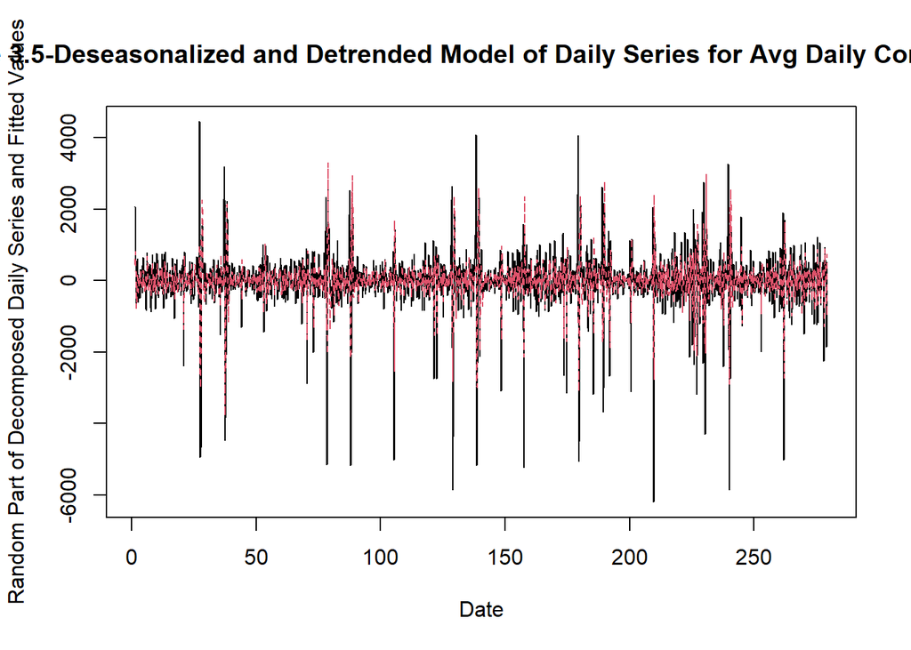

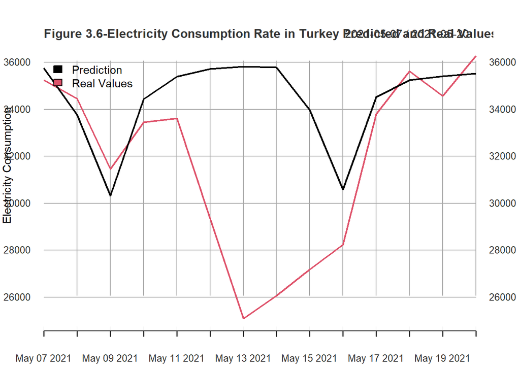

```
##            Deviation_as_Percentage2       Date
## 2021-05-07                 1.445270 2021-05-07
## 2021-05-08                 2.028247 2021-05-08
## 2021-05-09                 3.588685 2021-05-09
## 2021-05-10                 2.960268 2021-05-10
## 2021-05-11                 5.279804 2021-05-11
## 2021-05-12                21.765998 2021-05-12
## 2021-05-13                42.762420 2021-05-13
## 2021-05-14                37.320210 2021-05-14
## 2021-05-15                24.946440 2021-05-15
## 2021-05-16                 8.330492 2021-05-16
## 2021-05-17                 2.152326 2021-05-17
## 2021-05-18                 1.065075 2021-05-18
## 2021-05-19                 2.412089 2021-05-19
## 2021-05-20                 2.047876 2021-05-20
```

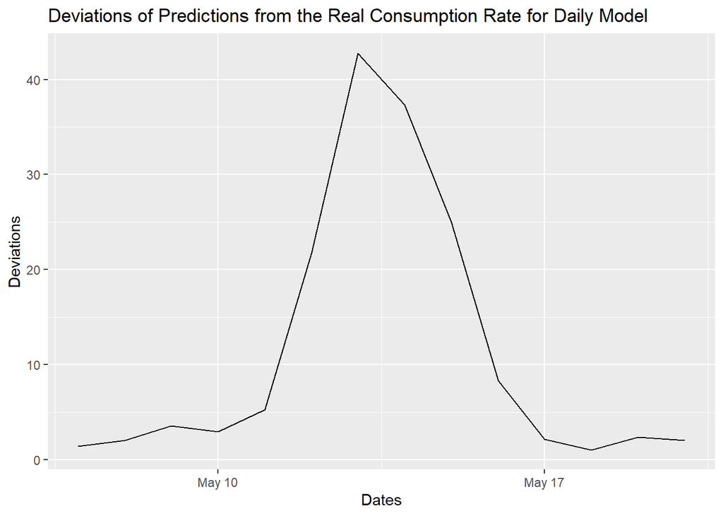

```
## [1] " Weighted Mean Absolute Percentage Error :  9.8473895652352"
```

Looking at the figures 3.5 and 3.6, the fitted values capture the most of the real values’ behaviour, however deviations exist. In figure 3.6 we can observe how the predicted values and real values are fitted, the predicted values capture the real values’ behaviour but still there is deviation from the real values. The deviation seem to have its peak around 13-16 May period, and this is the time in Ramadan Holiday in Turkey, since we don’t give the model this information, this may be the reason why the model is deviating from the real value.

# 4.) CONCLUSION

For predicting average daily electricity consumption values in Turkey, hourly series with 168 hour frequency and daiy series with 7 day frequency, both model’s deviation from the real values has its peak around 13-16 May period, since it coincides with Ramadan Holiday in Turkey, and special days information is not included in the model this may be one of the reasons why our model’s accuracy is low. In order to improve the model, these kind of information can be included in the model, also possible we can work on increasing the stationarity of the data.

Comparing the Weighted Mean Absolute Percentage Error of our prediction models with hourly series with 168 hour frequency and daiy series with 7 day frequency, even though they both are very close, daily series’ WMAPE values seem to be smaller, this may be an indicator that aggregating is a better solution in this case. This may be considered if we wish to develop the project further. Overall, we can say that both models work fine, deviation from the real valuesis not too big.